# Investigating the exponential distribution

Meenakshi Parameshwaran

25 January 2016

## Simulations

The code chunk below simulates the distribution of 1000 averages of 40 exponentials. Note that lambda (the rate) is 0.2 for all of the simulations.

```r
# simulating means
set.seed(seed = 1000) # set the seed
lambda = 0.2
mns = NULL
for (i in 1 : 1000) mns = c(mns, mean(rexp(n = 40, rate = lambda)))
```

The code chunk below simulates the distribution of 1000 variances of 40 exponentials.

```r
# simulating variances
set.seed(seed = 1) # set the seed
lambda = 0.2
vrs = NULL
for (i in 1 : 1000) vrs = c(vrs, var(rexp(n = 40, rate = lambda)))
```

## Sample Mean versus Theoretical Mean

The figure below shows a histogram of the simulated distribution of 1000 means of 40 exponential distributions. The theoretical mean of the exponential distribution is `1/lambda`, which is 5 (blue line). The sample mean of the simulated distribution is `mean(mns)` which is 4.9869634 (red line).

Because the simulated mean is very close to the theoretical mean, the red and blue lines are essentially overlapping. This indicates that the simulated mean is a good approximation of the theoretical mean of the exponential distribution.

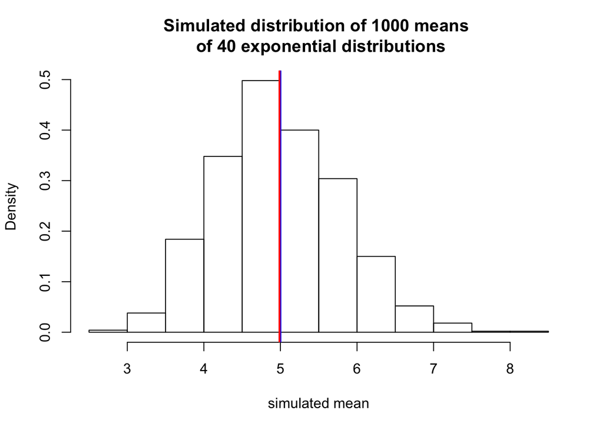

```r
# histogram
hist(mns, xlab = "simulated mean", main = "Simulated distribution of 1000 means \n of 40 exponential distributions",
    freq = FALSE)

# add theoretical mean line
abline(v = 1/lambda, col = "blue", lwd = 2)

# add simulated mean line
abline(v = mean(mns), col = "red", lwd = 2)
```

## Sample Variance versus Theoretical Variance

The figure below shows a histogram of the simulated distribution of 1000 variances of 40 exponential distributions. The theoretical variance of the exponential distribution is the standard deviation squared i.e. `(1/lambda)^2`, which is 25 (blue line). The mean sample variance of the simulated distribution is `mean(vrs)` which is 25.064586 (red line).

Because the simulated mean sample variance is very close to the theoretical variance, the red and blue lines are almost perfectly overlapping. This indicates that the sample variance is a good approximation of the theoretical variance of the exponential distribution.

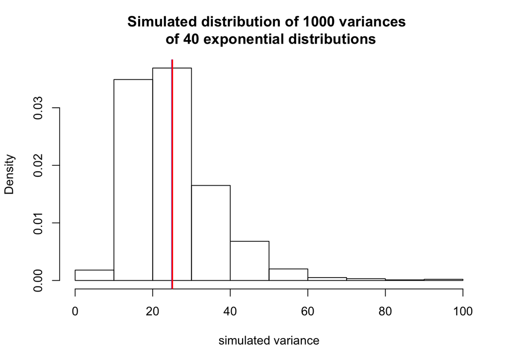

```r
# histogram
hist(vrs, xlab = "simulated variance", main = "Simulated distribution of 1000 variances \n of 40 exponential distributions",
    freq = FALSE)

# add theoretical variance line
abline(v = (1/lambda)^2, col = "blue", lwd = 2)

# add simulated variance line
abline(v = mean(vrs), col = "red", lwd = 2)
```

## Distribution

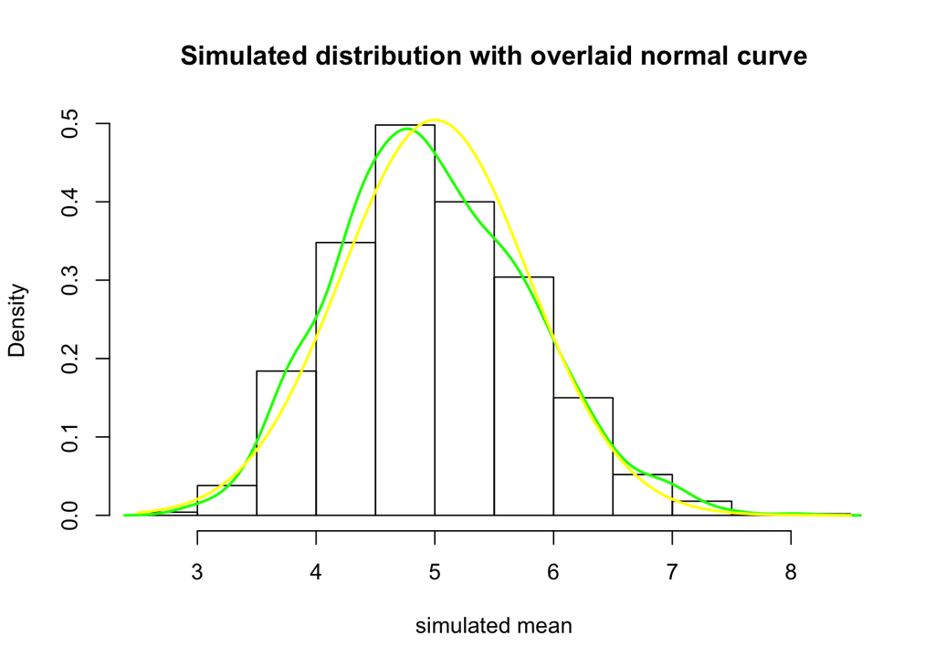

```r
# histogram
hist(mns, xlab = "simulated mean",
     main = "Simulated distribution with overlaid normal curve",
     freq = FALSE)

# overlay density plot of simulated means
lines(density(mns), col = "green", lwd = 2)

# overlay true normal density plot
x <- seq(from = min(mns), to = max(mns), by = 0.01) # create x values
curve(dnorm(x = x, mean = 1/lambda, sd = (1/lambda)/sqrt(40)), add = TRUE, col = "yellow", lwd = 2) # plot normal curve according to true mean and sd of exponential distribution for the values of x created above
```